# Test notebook

This notebook showcases the publication of our results using HTML-exported jupyter notebooks. We use the following packages:

- numpy
- pandas
- matplotlib
- plotly
- timeeval

## Load results

We read the results from the TimeEval experiment `2021-12-03_runtime-gutentag-2-merged`. It contains the evaluation of all our 61 considered algorithms with their optimized parameter settings on the synthetically generated GutenTAG datasets. The GutenTAG collection contains 193 datasets that can be used for semi-supervised, supervised, and unsupervised training.

We used the following algorithms:

| algo_input_dimensionality | algo_training_type | algorithm | # datasets |
| --- | --- | --- | --- |
| UNIVARIATE | UNSUPERVISED | VALMOD | 168 |
|  |  | Triple ES (Holt-Winter's) | 168 |
|  |  | TSBitmap | 168 |
|  |  | Subsequence LOF | 168 |
|  |  | Subsequence IF | 168 |
|  |  | Spectral Residual (SR) | 168 |
|  |  | Series2Graph | 168 |
|  |  | STOMP | 168 |
|  |  | STAMP | 168 |
|  |  | SSA | 168 |
|  |  | SAND | 168 |
|  |  | S-H-ESD (Twitter) | 168 |
|  |  | PhaseSpace-SVM | 168 |
|  |  | PST | 168 |
|  |  | PCI | 168 |
|  |  | NumentaHTM | 168 |
|  |  | NormA | 168 |
|  |  | MedianMethod | 168 |
|  |  | Left STAMPi | 168 |
|  |  | HOT SAX | 168 |
|  |  | GrammarViz | 168 |
|  |  | FFT | 168 |
|  |  | DWT-MLEAD | 168 |
|  |  | DSPOT | 168 |
|  |  | ARIMA | 168 |
|  | SEMI_SUPERVISED | XGBoosting (RR) | 168 |
|  |  | TARZAN | 168 |
|  |  | SR-CNN | 168 |
|  |  | Random Forest Regressor (RR) | 168 |
|  |  | OceanWNN | 168 |
|  |  | ImageEmbeddingCAE | 168 |
|  |  | Donut | 168 |
|  |  | Bagel | 168 |
| MULTIVARIATE | UNSUPERVISED | normal | 193 |
|  |  | k-Means | 193 |
|  |  | Torsk | 193 |
|  |  | PCC | 193 |
|  |  | LOF | 193 |
|  |  | KNN | 193 |
|  |  | Isolation Forest (iForest) | 193 |
|  |  | IF-LOF | 193 |
|  |  | HBOS | 193 |
|  |  | Extended Isolation Forest (EIF) | 193 |
|  |  | DBStream | 193 |
|  |  | COPOD | 193 |
|  |  | COF | 193 |
|  |  | CBLOF | 193 |
|  | SUPERVISED | Normalizing Flows | 193 |
|  |  | MultiHMM | 193 |
|  |  | Hybrid Isolation Forest (HIF) | 193 |
|  | SEMI_SUPERVISED | Telemanom | 193 |
|  |  | TAnoGan | 193 |
|  |  | RobustPCA | 193 |
|  |  | Random Black Forest (RR) | 193 |
|  |  | OmniAnomaly | 193 |
|  |  | LaserDBN | 193 |
|  |  | LSTM-AD | 193 |
|  |  | Hybrid KNN | 193 |
|  |  | HealthESN | 193 |
|  |  | EncDec-AD | 193 |
|  |  | DeepAnT | 193 |

The number of datasets, the algorithms were executed on, is different for univariate and multivariate algorithms, because the multivariate algorithms were also executed on the univariate datasets. The univariate algorithms cannot be executed on multivariate datasets, because they can't handle the multidimensional input.

This is also reflected in the number of algorithm executed per dataset, as can be seen in the following table showing the used datasets:

| collection | dataset_input_dimensionality | dataset_name | algorithm |
| --- | --- | --- | --- |
| GutenTAG | MULTIVARIATE | cbf-channels-all-of-3 | 28 |
|  |  | cbf-channels-single-of-10 | 28 |
|  |  | cbf-channels-single-of-2 | 28 |
|  |  | cbf-channels-single-of-20 | 28 |
|  |  | cbf-channels-single-of-5 | 28 |
|  |  | ecg-channels-all-of-3 | 28 |
|  |  | ecg-channels-single-of-10 | 28 |
|  |  | ecg-channels-single-of-2 | 28 |
|  |  | ecg-channels-single-of-20 | 28 |
|  |  | ecg-channels-single-of-5 | 28 |
|  |  | poly-channels-all-of-3 | 28 |
|  |  | poly-channels-single-of-10 | 28 |
|  |  | poly-channels-single-of-2 | 28 |
|  |  | poly-channels-single-of-20 | 28 |
|  |  | poly-channels-single-of-5 | 28 |
|  |  | rw-channels-all-of-3 | 28 |
|  |  | rw-channels-single-of-10 | 28 |
|  |  | rw-channels-single-of-2 | 28 |
|  |  | rw-channels-single-of-20 | 28 |
|  |  | rw-channels-single-of-5 | 28 |
|  |  | sinus-channels-all-of-3 | 28 |
|  |  | sinus-channels-single-of-10 | 28 |
|  |  | sinus-channels-single-of-2 | 28 |
|  |  | sinus-channels-single-of-20 | 28 |
|  |  | sinus-channels-single-of-5 | 28 |
|  | UNIVARIATE | cbf-combined-diff-1 | 61 |
|  |  | cbf-combined-diff-2 | 61 |
|  |  | cbf-combined-diff-3 | 61 |
|  |  | cbf-diff-count-1 | 61 |
|  |  | cbf-diff-count-2 | 61 |

[output cut: 163 more lines]

## Analyze overall results on the GutenTAG datasets

Some test analysis:

### Algorithm problems grouped by algorithm training type

SEMI_SUPERVISED

| algo_input_dimensionality | status algorithm | Status.ERROR | Status.OK | Status.TIMEOUT | ALL |
| --- | --- | --- | --- | --- | --- |
| UNIVARIATE | TARZAN | 33 | 135 | 0 | 168 |
|  | Bagel | 0 | 168 | 0 | 168 |
|  | Donut | 0 | 168 | 0 | 168 |
|  | ImageEmbeddingCAE | 0 | 168 | 0 | 168 |
|  | OceanWNN | 0 | 168 | 0 | 168 |
|  | Random Forest Regressor (RR) | 0 | 168 | 0 | 168 |
|  | SR-CNN | 0 | 168 | 0 | 168 |
|  | XGBoosting (RR) | 0 | 168 | 0 | 168 |
| MULTIVARIATE | LSTM-AD | 103 | 81 | 9 | 193 |
|  | EncDec-AD | 40 | 17 | 136 | 193 |
|  | LaserDBN | 25 | 168 | 0 | 193 |
|  | DeepAnT | 10 | 183 | 0 | 193 |
|  | OmniAnomaly | 4 | 189 | 0 | 193 |
|  | HealthESN | 0 | 155 | 38 | 193 |
|  | Hybrid KNN | 0 | 193 | 0 | 193 |
|  | Random Black Forest (RR) | 0 | 179 | 14 | 193 |
|  | RobustPCA | 0 | 193 | 0 | 193 |
|  | TAnoGan | 0 | 73 | 120 | 193 |
|  | Telemanom | 0 | 193 | 0 | 193 |

SUPERVISED

| algo_input_dimensionality | status algorithm | Status.ERROR | Status.OK | Status.TIMEOUT | ALL |
| --- | --- | --- | --- | --- | --- |
| MULTIVARIATE | MultiHMM | 98 | 95 | 0 | 193 |
|  | Normalizing Flows | 10 | 66 | 117 | 193 |
|  | Hybrid Isolation Forest (HIF) | 0 | 193 | 0 | 193 |

UNSUPERVISED

| algo_input_dimensionality | status algorithm | Status.ERROR | Status.OK | Status.TIMEOUT | ALL |
| --- | --- | --- | --- | --- | --- |
| UNIVARIATE | SAND | 28 | 140 | 0 | 168 |
|  | VALMOD | 8 | 160 | 0 | 168 |
|  | Series2Graph | 4 | 164 | 0 | 168 |
|  | Left STAMPi | 1 | 167 | 0 | 168 |
|  | ARIMA | 0 | 168 | 0 | 168 |
|  | DSPOT | 0 | 165 | 3 | 168 |
|  | DWT-MLEAD | 0 | 168 | 0 | 168 |
|  | FFT | 0 | 168 | 0 | 168 |
|  | GrammarViz | 0 | 168 | 0 | 168 |
|  | HOT SAX | 0 | 119 | 49 | 168 |
|  | MedianMethod | 0 | 168 | 0 | 168 |
|  | NormA | 0 | 158 | 10 | 168 |
|  | NumentaHTM | 0 | 168 | 0 | 168 |
|  | PCI | 0 | 168 | 0 | 168 |
|  | PST | 0 | 168 | 0 | 168 |
|  | PhaseSpace-SVM | 0 | 168 | 0 | 168 |
|  | S-H-ESD (Twitter) | 0 | 168 | 0 | 168 |
|  | SSA | 0 | 168 | 0 | 168 |
|  | STAMP | 0 | 168 | 0 | 168 |
|  | STOMP | 0 | 168 | 0 | 168 |
|  | Spectral Residual (SR) | 0 | 168 | 0 | 168 |
|  | Subsequence IF | 0 | 168 | 0 | 168 |
|  | Subsequence LOF | 0 | 168 | 0 | 168 |
|  | TSBitmap | 0 | 168 | 0 | 168 |
|  | Triple ES (Holt-Winter's) | 0 | 168 | 0 | 168 |
| MULTIVARIATE | DBStream | 160 | 33 | 0 | 193 |
|  | CBLOF | 0 | 193 | 0 | 193 |
|  | COF | 0 | 193 | 0 | 193 |
|  | COPOD | 0 | 193 | 0 | 193 |
|  | Extended Isolation Forest (EIF) | 0 | 193 | 0 | 193 |
|  | HBOS | 0 | 193 | 0 | 193 |
|  | IF-LOF | 0 | 193 | 0 | 193 |
|  | Isolation Forest (iForest) | 0 | 193 | 0 | 193 |
|  | KNN | 0 | 193 | 0 | 193 |
|  | LOF | 0 | 193 | 0 | 193 |
|  | PCC | 0 | 193 | 0 | 193 |
|  | Torsk | 0 | 186 | 7 | 193 |
|  | k-Means | 0 | 193 | 0 | 193 |
|  | normal | 0 | 193 | 0 | 193 |

### Algorithm quality assessment based on ROC_AUC

ROC_AUC score distribution for each algorithm:

| algorithm | LSTM-AD | Subsequence LOF | PhaseSpace-SVM | DWT-MLEAD | SAND | Donut | GrammarViz | EncDec-AD | Left STAMPi | Torsk | Normalizing Flows | STOMP | STAMP | k-Means | VALMOD | Series2Graph | Telemanom | Random Forest Regressor (RR) | XGBoosting (RR) | ImageEmbeddingCAE | HealthESN | Random Black Forest (RR) | ARIMA | PST | NormA | SSA | Subsequence IF | HOT SAX | OceanWNN | … |
| --- | --- | --- | --- | --- | --- | --- | --- | --- | --- | --- | --- | --- | --- | --- | --- | --- | --- | --- | --- | --- | --- | --- | --- | --- | --- | --- | --- | --- | --- | --- |
| min | 0.123730 | 0.341819 | 0.307866 | 0.125859 | 0.167172 | 0.151962 | 0.207808 | 0.344264 | 0.126879 | 0.077172 | 0.004679 | 0.009910 | 0.009910 | 0.000000 | 0.055046 | 0.069038 | 0.092208 | 0.405782 | 0.347727 | 0.106465 | 0.107862 | 0.130278 | 0.050505 | 0.016049 | 0.013301 | 0.114735 | 0.000020 | 0.147374 | 0.156114 | … |
| mean | 0.965738 | 0.929827 | 0.910840 | 0.896714 | 0.891497 | 0.887319 | 0.883153 | 0.877664 | 0.873368 | 0.872211 | 0.869716 | 0.867883 | 0.865997 | 0.860521 | 0.853179 | 0.852389 | 0.851876 | 0.851052 | 0.845629 | 0.841571 | 0.839642 | 0.808323 | 0.808085 | 0.796201 | 0.780556 | 0.762730 | 0.755168 | 0.727874 | 0.725467 | … |
| median | 0.996443 | 0.995447 | 0.976925 | 0.970002 | 0.983695 | 0.967975 | 0.989839 | 0.999900 | 0.980800 | 0.974609 | 0.994933 | 0.987088 | 0.987088 | 0.996880 | 0.958518 | 0.939665 | 0.975538 | 0.882308 | 0.880401 | 0.939670 | 0.913786 | 0.842815 | 0.884476 | 0.858833 | 0.926484 | 0.836139 | 0.837340 | 0.754119 | 0.746443 | … |
| max | 1.000000 | 1.000000 | 0.999928 | 0.999992 | 1.000000 | 1.000000 | 1.000000 | 1.000000 | 1.000000 | 0.999990 | 1.000000 | 1.000000 | 1.000000 | 1.000000 | 1.000000 | 1.000000 | 1.000000 | 1.000000 | 1.000000 | 0.998586 | 1.000000 | 1.000000 | 1.000000 | 1.000000 | 1.000000 | 0.999800 | 1.000000 | 1.000000 | 1.000000 | … |

The following plot shows the ROC_AUC scores for each algorithm over its processed datasets using a box plot. Note that some algorithms could execute only a fraction of the datasets. We show the number of failed datasets in braces next to the algorithm name.'

[interactive chart not shown]

The best five algorithms are LSTM-AD, Subsequence LOF, PhaseSpace-SVM, DWT-MLEAD, SAND

#### Scores of best algorithms

The next plot shows the scorings of the best 5 algorithms on the dataset `poly-same-count-2`.

[interactive chart not shown]

#### Reliability of reported AUC-ROC values

In the next plot, we show the ROC_AUC score of each algorithm in relation to its relative number of processed datasets.

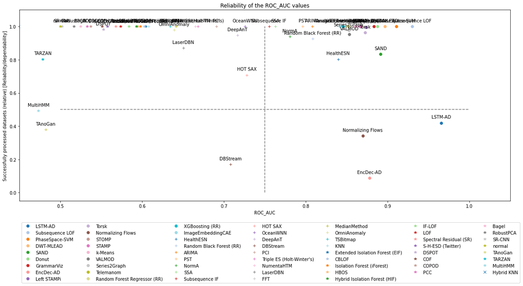

### Runtime-weighted AUC_ROC scores

[interactive chart not shown]